# coherence & proposition

measuring reference distance in :schizophrenia: threads

st. schwarz

2026-11-08

# index

Hausarbeit im Seminar: *Sprache und Psychose (PHILGEIST_S_16827_25S)*  
Dozent: Anatol Stefanowitsch  
abgegeben von: stschwarz  
MtrNr: placeholder  
abgegeben am: 2025-10-18  
an: Freie Universität Berlin

## Selbständigkeitserklärung

Hiermit versichere ich,

- dass ich die von mir vorgelegte Arbeit mit dem Titel

**coherence & propositions: measuring reference distance in :schizophrenia: threads**

selbständig abgefasst habe und

- dass ich keine weiteren Hilfsmittel verwendet habe als diejenigen, die im Vorfeld explizit zugelassen und von mir angegeben wurden und
- dass ich die Stellen der Arbeit, die dem Wortlaut oder dem Sinn nach anderen Werken (dazu zählen auch Internetquellen und KI-basierte Tools) entnommen sind, unter Angabe der Quelle kenntlich gemacht habe und
- dass ich, sollte ich explizit im Vorfeld zugelassene Hilfsmittel (z.B. KI-Tools) verwendet haben, diese in einer tabellarischen Übersicht (@ref(tab:kitable)) in meiner schriftlichen Arbeit integriert habe und
- dass ich die vorliegende Arbeit noch nicht für andere Prüfungen eingereicht habe.

Mir ist außerdem bewusst,

- dass ich diese Prüfung nicht bestanden habe, wenn ich die mir bekannte Frist für die Einreichung meiner schriftlichen Arbeit versäume und
- dass ich im Falle eines Täuschungsversuchs diese Prüfung nicht bestanden habe und
- dass ich im Falle eines schwerwiegenden Täuschungsversuchs ggf. die Gesamtprüfung endgültig nicht bestanden habe und in diesem Studiengang bzw. Studienangebot nicht mehr weiter studieren darf und
- dass ich, sofern ich zur Erstellung dieser Arbeit KI-basierte Tools verwendet habe, die Verantwortung für durch die KI generierte eventuell fehlerhafte oder verzerrte (bias) Inhalte, fehlerhafte Referenzen, Verstöße gegen das Datenschutz- und Urheberrecht oder Plagiate trage.

Ich bestätige mit meiner Unterschrift die Richtigkeit dieser Angaben.

2026-11-08,

# 15303.ha.final

## abstract

In this paper we want to explore **reference marking and coherence in schizophrenia language** by measuring corpus distance of similar nouns preceded by specified determinants.

Inspired by Zimmerer et al. (2017) we are interested in observations concerning coherence and propositional statement conditions in schizophrenia language. Further Nenchev et al. (2024) consider investigating in coherence as important “linguistic aspect in psychotic language addressing the relatedness between word chunks or sentences” an approach to “capture formal thought disorders (disorganisation, tangentiality, derailment and poverty of speech) in schizophrenia” (cf. Nenchev et al. (2024), 2.1: linguistic markers of schizophrenia). As this is not a clinical but a corpus linguistics study we do not intend to concur with recent psychiatric literature but rather take the subject as welcome task to test corpus linguistics methods.

Since above mentioned linguistic marker seems to play a crucial role within target group language features (and as such can be seen as asset of thinking- or world building capacity which might deviate from standard within the range of negative symptoms) we might with our approach add to the research done concerning frequency based analyses of how typical patients language might appear and how it deviates in terms of keywords or word fields. Our interest is more dedicated to the structural layer of the language which can not be described by raw frequencies. In our opionion disturbances on that layer might be hidden and not to grasp easily such that a listener would not always be able to precisely figure out what the disturbing factor is. Missing **coherence**, which we will investigate, may be a too narrow explanation to many impressions that schizophrene language leaves the listener with. But it seems to be a good starting point to unveiling structural patterns of patients language.

## definitions, terminology, assumptions

### coherence

There are several preliminary affordances to a successful communication. One is the *coherence* of a text = way of communication, which accounts for the partner being able to follow the topic and relate subjects and objects referenced. There can be more or less *common* references and such, that need to be embedded in context to be understood. The underlying network of informations to create that context is what we call *information structure* of a text. The level of complexity of that network defines how simple it would be to gather the reference from the given information. We might have to go back many sentences or even infer reference from metaphors or such to be able to understand what is said while in the other case simply recall the subject of the last sentence to get the meaning (reference) of the pronoun in `also {she} said thisandthat...`. The capacity to imagine or have in mind, what concrete information is accessible to the adressee (what he actually knows or can infer) is key to a successful communication, since factors like common-ness, weltwissen and shared knowledge between adressant and adressee and informations accessible from the text itself vary depending on topic, setting, intimacy of the partners and such. So one cannot always be sure that the information provided is sufficient but the grade to which one can give a correct estimate to this sufficiency should here be the measure assuming that coherence in disturbed language is deficient which lets an utterance be more difficult to understand within the frame of given information. Now one indicator of coherence we assume is *reference distance* where according to our hypothesis a larger distance would be observed in places where the adressant overestimates[^1] the ability of the partner to follow a reference. That would mean that we find a medium shorter distance between referent and reference in the reference corpus[^2] and larger distances in the target corpus. The references we are interested in are nouns that appear as anaphors i.e. here as noun analogies. The assumption is that if a noun is repeated *and* is combinded with certain preceding determiners, the speaker assumes that the adressee has some knowledge of what is talked about, depending on the strength of the determination. So e.g. this, that, those, these would be rather strong determiners requiring that the noun was introduced before.

### premises

#### deictic anchoring and propositional complexity

Zimmerer et al. (2017) consider “Deictic anchoring […] an inherent part of the process by which we make references to aspects in the world including entities, events, locations, and time.” and define propositions as being “statements about the world which can be true or false.” They mention, according to (Kuperberg 2010) “that in people with schizophrenia, cortical activity to semantic abnormalities in sentences is particularly small compared to controls if interpretation requires integration of several sentences” which can mean, that patients are not realising if their utterances are somehow disturbed on the semantics level. If “Delusions and thought disorder can be considered disruptions of propositional meaning” then the patients feeling for their stated propositions (required to the adressee) and further the estimation about what he/she can assume as familiar to the adressee can be wrong. Following Klaus Konrad (Mishara 2010) who “described the onset of a delusion as the loss of ability to transcend an experience and see it with the eyes of others” Zimmerer et al. (2017) assume that “in thought disorder, the ability to express coherent propositions can be severely impaired.” We take that as premise for our research question.

## questions

Measuring the referent-reference distance which we assume as an indicator for coherence we hope to find empirical evidence for disturbed or not world building capacities within schizophrenia language. Premising that a large noun distance indicates a low reference-referent association we hypothesise that in a language/ToM setting where the speakers estimation of the audiences context understanding capacities is disturbed we will find higer medium scores for the distance under matching conditions. An environment which has potential to test our hypothesis is a reddit.com subreddit where the majority of participants describe themselves as being diagnosed with schizophrenia.[^3] As reference corpus we chose reddit r/unpopularopinion. The distance measured should give us information structural evidence of how strong the noun occurences[^4] are connected, i.e. if a noun appears out of the blue mostly or if it somewhere before has been introduced to the audience and thus would be more or less legitimated to be determined by an antecedent. Our basic assumptions rely on the *taxonomy of given end new information* coined by Prince (1981). She develops a hierarchy of references[^5] with specific relations to each other, where each item is attributed in terms of *familiarity*[^6], that defines ranges of 1. givennes in the sense of predictability/recoverability, 2. givenness in the sense of saliency, 3. givenness in the sense of “shared knowledge”. (cf. Prince (1981), pp. 226) We base our hypothesis of *reference distance as indicator for coherence* on this model assuming that the reference/association strength[^7] determines the level of text coherence.

## data

data sample of distances df

| token | upos | target | pos | prepos | url_id | range | q | det | aut_id | total_mentions | dist | embed.score | dist_rel_within | dist_rel_all | dist_rel_obs | dist_rel_ref | embed_c | dist_rel_scaled |
| --- | --- | --- | --- | --- | --- | --- | --- | --- | --- | --- | --- | --- | --- | --- | --- | --- | --- | --- |
| son | NOUN | ref | 253202 | AUX | 1965 | 1517 | a | 0 | 5754 | 4 | 56 | 36.05 | 175 | 128 | 76 | 175 | -5.76 | 0.04 |
| night | NOUN | obs | 988303 | DET | 1519 | 2991 | a | 1 | 2683 | 7 | 1515 | 31.02 | 1036 | 1753 | 1036 | 2406 | -10.79 | 0.51 |
| thing | NOUN | obs | 273950 | ADJ | 479 | 1501 | a | 0 | 840 | 3 | 966 | 32.87 | 1317 | 2228 | 1317 | 3057 | -8.94 | 0.64 |
| managers | NOUN | ref | 418205 | PUNCT | 2021 | 5436 | a | 0 | 7104 | 2 | 3789 | 35.16 | 3311 | 2413 | 1426 | 3311 | -6.65 | 0.70 |
| year | NOUN | ref | 383663 | CCONJ | 2010 | 13678 | a | 0 | 6842 | 30 | 21 | 30.60 | 7 | 5 | 3 | 7 | -11.22 | 0.00 |
| experience | NOUN | obs | 981377 | ADJ | 1507 | 864 | a | 0 | 2674 | 2 | 296 | 45.74 | 701 | 1186 | 701 | 1627 | 3.93 | 0.34 |
| argument | NOUN | ref | 396528 | PRON | 2014 | 5289 | b | 0 | 6695 | 3 | 92 | 36.93 | 83 | 60 | 36 | 83 | -4.88 | 0.02 |
| media | NOUN | obs | 596671 | ADJ | 873 | 3756 | a | 0 | 117 | 9 | 536 | 40.87 | 292 | 494 | 292 | 678 | -0.94 | 0.14 |
| day | NOUN | obs | 1125024 | DET | 1669 | 2171 | b | 1 | 570 | 13 | 105 | 42.91 | 99 | 167 | 99 | 230 | 1.10 | 0.05 |
| school | NOUN | obs | 1094232 | ADJ | 1642 | 1197 | a | 0 | 124 | 4 | 4 | 28.93 | 7 | 12 | 7 | 16 | -12.88 | 0.00 |

## methods

To compute distances we queried the corpus for matching conditions where certain (probable) determiners appear before analogue nouns (anaphors).

| condition | value |  |
| --- | --- | --- |
| a | any !(b,c,d,e,f) |  |
| b | this, that, those, these |  |
| c | the |  |
| d | a, any, some |  |
| e | my |  |
| f | his, her, their, your |  |

We decided for these 5 sets of determiners in order to see wether distances maybe influenced if the duplicated nouns are preceded by them. We would expect condition **b** to show different if not reziproke effects as condition **d** [^8] and yet the texts in the reference corpus show the expected behaviour while in the target corpus not.

For each datapoint we collect variables as:

- thread url
- author (anonymised)
- thread length (tokens)
- lexical diversity (type/token ratio)
- lemma
- distance (to the preceding occurence, e.g. for three occurences of dog we collect 2 distance datapoints)

The main function to determine the distances runs on a subset of the corpus with only including all nouns and their position in the corpus. It finds all duplicated nouns per url thread and computes their distances by token position.

## reflections

### range

Evaluating with a growing corpus we interestingly find our basic hypothesis tested again, showing an overall larger distance of analogue nouns within the range of 1 thread url for the target corpus. While earlier we devised distances from a manually assigned url identifier we saw the necessity to define our “range of interest” according to the original http url of the thread, since with a growing corpus the old url ids - derived from the get_thread_url() method of the redditExtractoR package (Rivera (2023)) used for fetching the reddit content - there a no new url ids created since one url fetch gets each time always only around 1000 urls. To ensure unique url ranges within the corpus we assigned the range (within which the noun distance is calculated) to the real thread url. The corpus itself is after each fetch sorted after url and timestamp so it represents the real flow of conversation within one thread which is important since our distance model is based on the token distances within that thread and they have to follow their natural occurence in time.  
The url range is an important variable which we used for normalising the distance values since the mean distances could also depend on the overall thread length. For that we calculated for each normalisation method as are 1. per target, 2. within target and 3. cross target a range factor by which the distance values are divided. The final regression model posits fixed effects of condition, target, determiner, range and embed score (where target, condition and determiner are interacting) and random effects of thread and author.

### author trace id

An important integrated feature can be the aut_id variable which represents the comment author and is unique to that. In the base .sqlite database the authors are already anonymised, so there should be no way from the published data back to the original author name of the comment. And as expected, including aut_id as random effect in the linear regression model, the significance level for the covariables of interest as are

1. q = the condition matching of the noun-preceding token
2. det = wether that match has postag “DET”
3. target = obs or reference corpus

finally increases.

### lexical diversity

We thought about some serious caveats in modeling the evaluation: If (lucky for our hypothesis) the target corpus has significantly higher distance scores over nearly all conditions, does that automatically indicate a less coherent reference-referent association within what is expressed in the comments? Couldn’t we also assume that if the analogue nouns appear more distanced in general that a topic which is including these nouns is simply expanding over a wider range resp. timeframe? What does that mean for our assumptions in terms of coherence? A good way here could be to integrate a general lexical diversity factor per url as fixed effect because we can assume that a higher type/token ratio logically decreases the probability of a noun appearing multiple times within a range and we could take that effect into account.[^9]

### semantics, word field, embeddings

Further we created another covariable possible to integrate in the evaluation model: The semantic embedding of one specific noun appearing on its specific position in the thread range, computed with help of an open LL word embedding model (Nussbaum et al. (2024).) This is a common AI way of devising semantic relations in a corpus which exceeds a just frequency based keyword analysis. Using an LLM here allows for a distinctive identification of world field embeddings of the noun in question. In that way we get another variable linguistic feature extracted which may give general insights into the level of standardisation that applies to the corpora. So if a noun is found to be embedded with a high score into its context (the url thread) then it can be much expected to be found there and appears less out-of-context.[^10]

### statistics

In this context we thought about what it means statistically, if a high-score embedded word also ranks high in (distance) significance i.e. generally what the relations of the covariates in the context of the linear regression evaluation express. Let us picture this:

1. a word receives a high embed score if it is highly semantically related to the context within which it appears, here the comment thread.
2. therefore the necessity to introduce/elaborate on it sinks, since it may be considered a “known” or “inferable” entity within the context given.
3. now if a person is using this word, the determined use appears less incoherent by itself.
4. the reference distance thus may increase without losing in coherence.
5. **conclusion:** if we for our linear regression use a (base) formula like `distance ~ corpus` , a continuos `embed_score` predictor between `-1 and 1` should correlate positive with the estimates for `dist` if applied correctly?

### caveats

Since devising the word embed score does take much computing ressources we had a script run on a server that solves the computing. But the first essai to integrate the new var into the evaluation model failed due to levels < 2. Why? Because in the beginning we ran the script just over a few chunks of the complete url ranges in the corpus[^11] which is sorted after target,[^12] we did not compute any values for the reference corpus. So we learned this way again on linear regression models which require that a variable has more than one level (which would not be the case if the lmer() function excludes all NA rows: there simply would be no observations left with target=ref since all its embed.score values are NA (not yet calculated) and so all target.ref rows will be removed during regression.)  
The issue is solved since we found a ressource saving method of computing the embed scores with a local instance of ollama that provides an API to use the model.

## model evaluations

### covariances

In words:

*sidenote:* Positing the url range only as fixed effect instead of normalising the distances still estimates smaller distances for the reference corpus, but with no significance, the only significant difference with that regression formula shows in target=REF under condition e (antecedents: `my`).

## conclusion

After evaluating over the different approaches we find our hypothesis proved, that anaphora distances in the target corpus (target=OBS) stretch over a significantly (p<0.001) wider range of tokens between reference and referent in contrast to the chosen reference corpus. With our assumptions this could prove a less appropriate estimate for the coherence of the own texts produced in schizophrene language still having in mind, that a wider distance is not stating incoherence in general but instead just that these speakers allow for a wider anaphora distance in their text production. If these distances indeed lead to less coherent texts compared to the reference corpus must be subject to close reading and annotating samples manually and questioning them in terms of coherence by skilled readers though annotation may vary strongly depending on the disposition of readers and their general capacities of infering references. But if we agree that shorter reference distances increase text coherence then we might say the texts produced in the target corpus are less coherent than those in the reference corpus which alignes with the common classification of patients language in psychiatry.

## limitations

We had to do some silent assumptions, but the main limitation is that we will have to base our specification of the target corpus as being one that is containing schizophrene language mainly on the statements of the reddit users in our target corpus which do describe themselves as being diagnosed schizophrene to a large amount. To what extend these statements and assignments or identifications are true we cannot say and therefore limit the value of our findings only to that group of speakers.

# appendix

overall wordcount of paper: 3149.

## legende

model vars

| variable | explanation | values |
| --- | --- | --- |
| target | corpus | obs,ref |
| q | condition | a,b,c,d,e,f |
| det | antecedent POS==DET | TRUE,FALSE |
| aut_id | author | author hash |
| lemma | lemma | noun lemma |
| range | url range of distance devised | 1..maxlength(urlthread) |
| embed.score | semantic similarity score lemma vs. thread | 0:1 (scaled 0:100) |
| q:a | query condition | any !{b,c,d,e,f} |
| q:b | query condition | this,that,those,these |
| q:c | query condition | the |
| q:d | query condition | a,an,any,some |
| q:e | query condition | my |
| q:f | query condition | his,her,their,your |

## covariance effects in M1

```
## 12 x 12 Matrix of class "dpoMatrix"
##              (Intercept)  targetref          qb         qc         qd         qe
## (Intercept)    69862.146 -58795.662   -9148.342  -7061.664  -7322.707  -6501.486
## targetref     -58795.662  86677.951   10422.826   7314.726   7622.213   6228.395
## qb             -9148.342  10422.826  145493.177   7180.570   7098.196   6845.805
## qc             -7061.664   7314.726    7180.570  57436.149   7000.108   7022.333
## qd             -7322.707   7622.213    7098.196   7000.108  57699.256   6869.923
## qe             -6501.486   6228.395    6845.805   7022.333   6869.923  82043.963
## qf             -8557.277   9459.279    7812.646   7088.654   6958.620   6269.919
## targetref:qb    9035.104 -15143.786 -145491.904  -7179.952  -7099.244  -6846.785
## targetref:qc    7063.973 -11834.901   -7198.770 -57440.816  -7006.195  -7019.814
## targetref:qd    7266.294 -11936.046   -7084.556  -6999.125 -57695.428  -6872.985
## targetref:qe    6237.081 -10848.005   -6868.104  -7026.628  -6874.382 -82038.774
## targetref:qf    8727.878 -14381.051   -7805.717  -7085.408  -6956.788  -6271.239
##                       qf targetref:qb targetref:qc targetref:qd targetref:qe targetref:qf
## (Intercept)    -8557.277     9035.104     7063.973     7266.294     6237.081     8727.878
## targetref       9459.279   -15143.786   -11834.901   -11936.046   -10848.005   -14381.051
## qb              7812.646  -145491.904    -7198.770    -7084.556    -6868.104    -7805.717
## qc              7088.654    -7179.952   -57440.816    -6999.125    -7026.628    -7085.408
## qd              6958.620    -7099.244    -7006.195   -57695.428    -6874.382    -6956.788
## qe              6269.919    -6846.785    -7019.814    -6872.985   -82038.774    -6271.239
## qf            133563.494    -7821.086    -7098.942    -6950.523    -6286.334  -133557.533
## targetref:qb   -7821.086   394442.191    11856.855    11921.325    11453.891    12819.521
## targetref:qc   -7098.942    11856.855   274197.452    11768.335    11468.083    11725.784
## targetref:qd   -6950.523    11921.325    11768.335   243407.901    11279.807    11181.529
## targetref:qe   -6286.334    11453.891    11468.083    11279.807   491013.557     9992.966
## targetref:qf -133557.533    12819.521    11725.784    11181.529     9992.966   784124.488
```

## evaluation model: 1

### meta

eval output data: 13, not normalised, distance ceiling =outliers not removed

### parameter setting

```
##             value
## norm_target
## det.t       FALSE
## limit       FALSE
## author       TRUE
## url         FALSE
## embed1      FALSE
## embed2          f
## range1      FALSE
## range2          f
## rel         FALSE
## lme         FALSE
## lemma       FALSE
```

### anova analysis

#### anova plain

formula: [`dist ~ target*q`]

```
##                 Df     Sum Sq    Mean Sq  F value Pr(>F)
## target           1 1.1152e+11 1.1152e+11 268.8095 <2e-16 ***
## q                5 9.8792e+08 1.9758e+08   0.4763 0.7943
## target:q         5 2.3123e+09 4.6246e+08   1.1147 0.3500
## Residuals   142309 5.9040e+13 4.1487e+08
## ---
## Signif. codes:  0 '***' 0.001 '**' 0.01 '*' 0.05 '.' 0.1 ' ' 1
```

#### anova of linear regression model

[`anova(summary(lmer))`]

```
## Type III Analysis of Variance Table with Satterthwaite's method
##              Sum Sq    Mean Sq NumDF  DenDF F value  Pr(>F)
## target   2.7781e+10 2.7781e+10     1  41990 91.7947 < 2e-16 ***
## q        1.8310e+09 3.6620e+08     5 138098  1.2100 0.30138
## target:q 2.8602e+09 5.7204e+08     5 138097  1.8902 0.09239 .
## ---
## Signif. codes:  0 '***' 0.001 '**' 0.01 '*' 0.05 '.' 0.1 ' ' 1
```

#### linear regression coefficients

formula: [`dist ~ target*q+(1|aut_id)`]

```
## Linear mixed model fit by REML. t-tests use Satterthwaite's method ['lmerModLmerTest']
## Formula: eval(expr(lmeform))
##    Data: dfa
##
## REML criterion at convergence: 3196742
##
## Scaled residuals:
##     Min      1Q  Median      3Q     Max
## -14.660  -0.028  -0.012   0.005  54.229
##
## Random effects:
##  Groups   Name        Variance  Std.Dev.
##  aut_id   (Intercept) 178036632 13343
##  Residual             302640356 17397
## Number of obs: 142321, groups:  aut_id, 8395
##
## Fixed effects:
##              Estimate Std. Error       df t value Pr(>|t|)
## (Intercept)    -808.7      264.3  11889.1  -3.060  0.00222 **
## targetref      3452.4      294.4  19277.3  11.727  < 2e-16 ***
## qb             -546.7      381.4 136741.8  -1.433  0.15177
## qc              125.6      239.7 136333.6   0.524  0.60012
## qd             -192.6      240.2 136351.0  -0.802  0.42277
## qe             -140.9      286.4 136799.0  -0.492  0.62273
## qf             -592.2      365.5 136840.7  -1.620  0.10517
## targetref:qb    625.4      628.0 138072.4   0.996  0.31932
## targetref:qc  -1420.1      523.6 137894.8  -2.712  0.00669 **
## targetref:qd    285.6      493.4 137740.9   0.579  0.56270
## targetref:qe    287.0      700.7 138617.5   0.410  0.68210
## targetref:qf    430.0      885.5 138149.2   0.486  0.62726
## ---
## Signif. codes:  0 '***' 0.001 '**' 0.01 '*' 0.05 '.' 0.1 ' ' 1
##
## Correlation of Fixed Effects:
##             (Intr) trgtrf qb     qc     qd     qe     qf     trgtrf:qb trgtrf:qc trgtrf:qd
## targetref   -0.756
## qb          -0.091  0.093
## qc          -0.111  0.104  0.079
## qd          -0.115  0.108  0.077  0.122
## qe          -0.086  0.074  0.063  0.102  0.100
## qf          -0.089  0.088  0.056  0.081  0.079  0.060
## targetrf:qb  0.054 -0.082 -0.607 -0.048 -0.047 -0.038 -0.034
## targetrf:qc  0.051 -0.077 -0.036 -0.458 -0.056 -0.047 -0.037  0.036
## targetrf:qd  0.056 -0.082 -0.038 -0.059 -0.487 -0.049 -0.039  0.038     0.046
## targetref:q  0.034 -0.053 -0.026 -0.042 -0.041 -0.409 -0.025  0.026     0.031     0.033
## targetrf:qf  0.037 -0.055 -0.023 -0.033 -0.033 -0.025 -0.413  0.023     0.025     0.026
##             targtrf:q
## targetref
## qb
## qc
## qd
## qe
## qf
## targetrf:qb
## targetrf:qc
## targetrf:qd
## targetref:q
## targetrf:qf  0.016
```

### plots

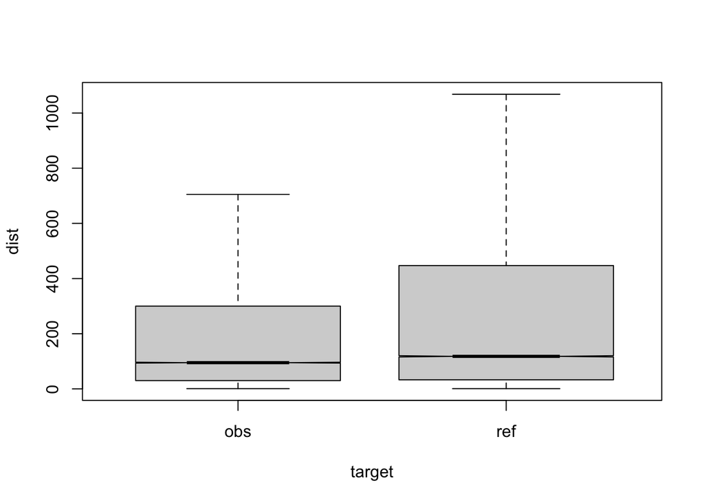

compare distances by corpus, not normalised, distance ceiling =outliers not removed

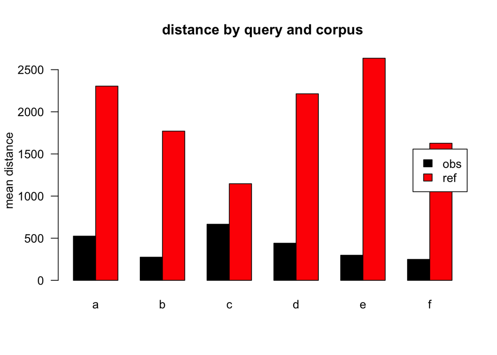

mean distances over query/corpus, not normalised, distance ceiling =outliers not removed

mean/median table for model: 1

| target | q | n | mean | median |
| --- | --- | --- | --- | --- |
| obs | a | 46318 | 525 | 92 |
| ref | a | 68618 | 2305 | 118 |
| obs | b | 2287 | 275 | 109 |
| ref | b | 1315 | 1771 | 111 |
| obs | c | 6253 | 666 | 89 |
| ref | c | 1504 | 1147 | 119 |
| obs | d | 6171 | 441 | 105 |
| ref | d | 1765 | 2214 | 124 |
| obs | e | 4278 | 298 | 109 |
| ref | e | 795 | 2636 | 116 |
| obs | f | 2520 | 249 | 77 |
| ref | f | 497 | 1627 | 124 |

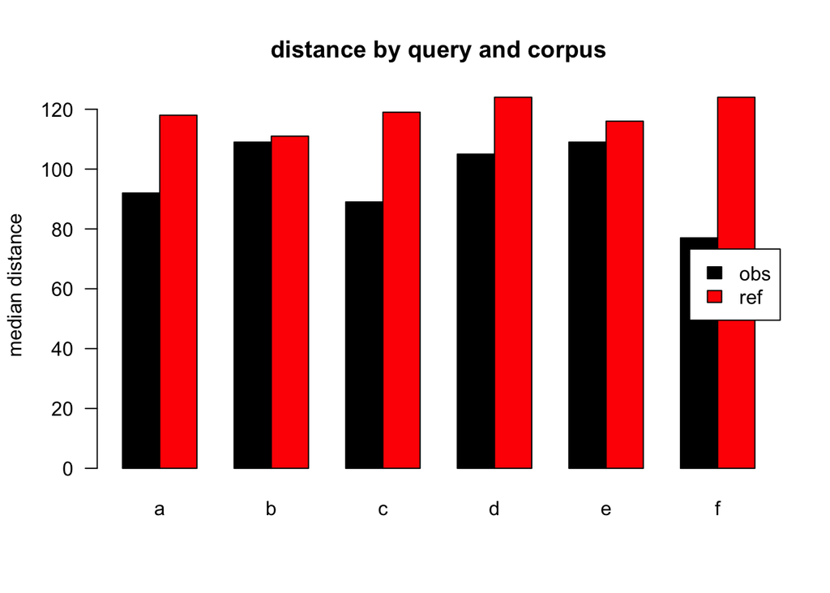

median distances over query/corpus, not normalised, distance ceiling =outliers not removed

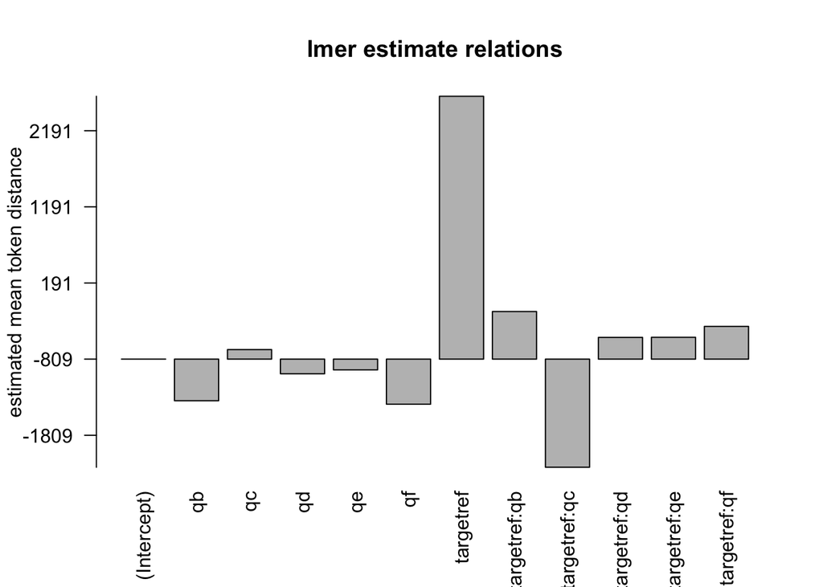

distances relation, not normalised, distance ceiling =outliers not removed

## evaluation model: 2

### meta

eval output data: 13, not normalised, distance ceiling =outliers removed

### parameter setting

```
##                value
## norm_target _rel_all
## det.t          FALSE
## limit           TRUE
## author          TRUE
## url            FALSE
## embed1         FALSE
## embed2             f
## range1         FALSE
## range2             f
## rel            FALSE
## lme            FALSE
## lemma          FALSE
```

### anova analysis

#### anova plain

formula: [`dist ~ target*q`]

```
##                 Df     Sum Sq Mean Sq F value    Pr(>F)
## target           1    3284330 3284330 84.1188 < 2.2e-16 ***
## q                5    1633205  326641  8.3660 6.395e-08 ***
## target:q         5     518143  103629  2.6542   0.02097 *
## Residuals   126214 4927893100   39044
## ---
## Signif. codes:  0 '***' 0.001 '**' 0.01 '*' 0.05 '.' 0.1 ' ' 1
```

#### anova of linear regression model

[`anova(summary(lmer))`]

```
## Type III Analysis of Variance Table with Satterthwaite's method
##          Sum Sq Mean Sq NumDF  DenDF F value    Pr(>F)
## target   747981  747981     1  36991 20.1114 7.328e-06 ***
## q        375456   75091     5 125595  2.0190   0.07259 .
## target:q 440069   88014     5 125595  2.3665   0.03716 *
## ---
## Signif. codes:  0 '***' 0.001 '**' 0.01 '*' 0.05 '.' 0.1 ' ' 1
```

#### linear regression coefficients

formula: [`dist ~ target*q+(1|aut_id)`]

```
## Linear mixed model fit by REML. t-tests use Satterthwaite's method ['lmerModLmerTest']
## Formula: eval(expr(lmeform))
##    Data: dfa
##
## REML criterion at convergence: 1690119
##
## Scaled residuals:
##     Min      1Q  Median      3Q     Max
## -1.9671 -0.6639 -0.3983  0.3356  3.9390
##
## Random effects:
##  Groups   Name        Variance Std.Dev.
##  aut_id   (Intercept)  2186     46.75
##  Residual             37192    192.85
## Number of obs: 126226, groups:  aut_id, 8238
##
## Fixed effects:
##                Estimate Std. Error         df t value Pr(>|t|)
## (Intercept)     156.240      1.585   4816.315  98.583  < 2e-16 ***
## targetref        16.859      1.944   5894.560   8.673  < 2e-16 ***
## qb                9.612      4.356 124373.970   2.207 0.027344 *
## qc               -1.918      2.742 124483.755  -0.700 0.484224
## qd               10.504      2.759 124184.640   3.807 0.000141 ***
## qe               10.449      3.283 125528.231   3.183 0.001458 **
## qf              -15.546      4.189 125038.526  -3.711 0.000207 ***
## targetref:qb    -12.647      7.306 125458.196  -1.731 0.083430 .
## targetref:qc      4.955      6.168 125420.115   0.803 0.421822
## targetref:qd     -5.464      5.768 125455.694  -0.947 0.343516
## targetref:qe    -17.843      8.261 125850.214  -2.160 0.030786 *
## targetref:qf     16.717     10.517 125775.551   1.589 0.111950
## ---
## Signif. codes:  0 '***' 0.001 '**' 0.01 '*' 0.05 '.' 0.1 ' ' 1
##
## Correlation of Fixed Effects:
##             (Intr) trgtrf qb     qc     qd     qe     qf     trgtrf:qb trgtrf:qc trgtrf:qd
## targetref   -0.787
## qb          -0.135  0.116
## qc          -0.205  0.169  0.078
## qd          -0.207  0.171  0.077  0.121
## qe          -0.178  0.143  0.062  0.101  0.098
## qf          -0.140  0.118  0.056  0.080  0.079  0.061
## targetrf:qb  0.080 -0.116 -0.596 -0.047 -0.046 -0.037 -0.033
## targetrf:qc  0.091 -0.128 -0.035 -0.445 -0.054 -0.045 -0.036  0.035
## targetrf:qd  0.099 -0.138 -0.037 -0.058 -0.478 -0.047 -0.038  0.038     0.044
## targetref:q  0.070 -0.098 -0.025 -0.040 -0.039 -0.397 -0.024  0.025     0.030     0.032
## targetrf:qf  0.056 -0.080 -0.022 -0.032 -0.031 -0.024 -0.398  0.022     0.024     0.025
##             targtrf:q
## targetref
## qb
## qc
## qd
## qe
## qf
## targetrf:qb
## targetrf:qc
## targetrf:qd
## targetref:q
## targetrf:qf  0.016
```

### plots

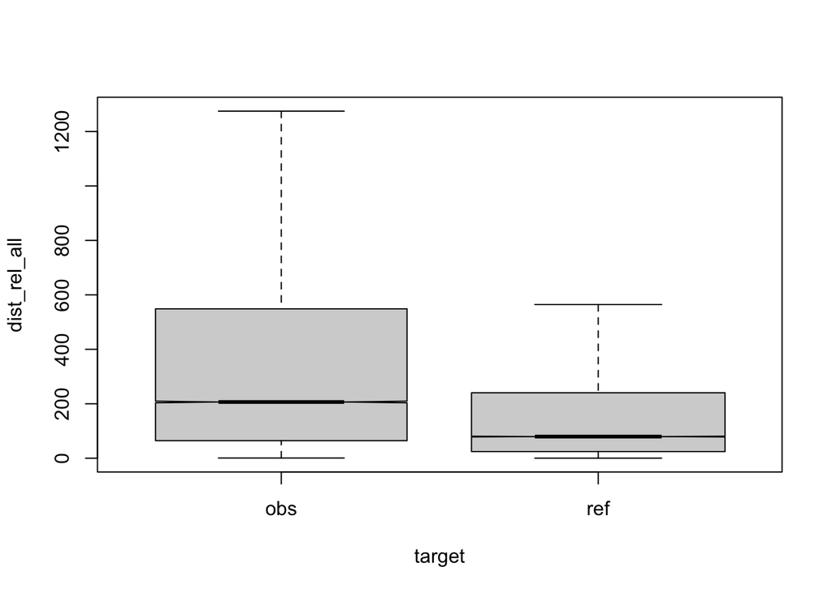

mean/median table for model: 2

| target | q | n | mean | median |
| --- | --- | --- | --- | --- |
| obs | a | 42836 | 161 | 77 |
| ref | a | 58615 | 172 | 81 |
| obs | b | 2116 | 169 | 109 |
| ref | b | 1130 | 168 | 78 |
| obs | c | 5770 | 159 | 75 |
| ref | c | 1274 | 175 | 84 |
| obs | d | 5654 | 170 | 86 |
| ref | d | 1525 | 176 | 83 |
| obs | e | 3911 | 175 | 92 |
| ref | e | 671 | 165 | 71 |
| obs | f | 2311 | 144 | 62 |
| ref | f | 413 | 171 | 82 |

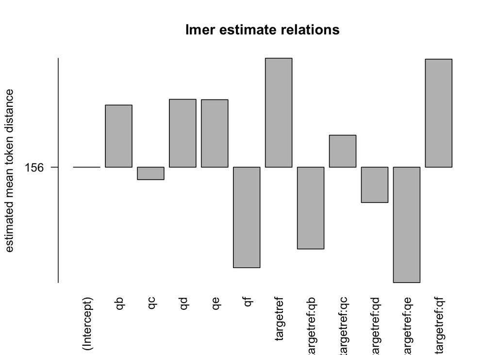

distances relation, not normalised, distance ceiling =outliers removed

## evaluation model: 3

### meta

eval output data: 13, normalised to all, distance ceiling = outliers removed

### parameter setting

```
##                value
## norm_target _rel_all
## det.t          FALSE
## limit           TRUE
## author          TRUE
## url            FALSE
## embed1         FALSE
## embed2             f
## range1         FALSE
## range2             f
## rel             TRUE
## lme            FALSE
## lemma          FALSE
```

### anova analysis

#### anova plain

formula: [`dist ~ target*q`]

```
##                 Df     Sum Sq Mean Sq F value    Pr(>F)
## target           1    3284330 3284330 84.1188 < 2.2e-16 ***
## q                5    1633205  326641  8.3660 6.395e-08 ***
## target:q         5     518143  103629  2.6542   0.02097 *
## Residuals   126214 4927893100   39044
## ---
## Signif. codes:  0 '***' 0.001 '**' 0.01 '*' 0.05 '.' 0.1 ' ' 1
```

#### anova of linear regression model

[`anova(summary(lmer))`]

```
## Type III Analysis of Variance Table with Satterthwaite's method
##          Sum Sq Mean Sq NumDF  DenDF F value    Pr(>F)
## target   747981  747981     1  36991 20.1114 7.328e-06 ***
## q        375456   75091     5 125595  2.0190   0.07259 .
## target:q 440069   88014     5 125595  2.3665   0.03716 *
## ---
## Signif. codes:  0 '***' 0.001 '**' 0.01 '*' 0.05 '.' 0.1 ' ' 1
```

#### linear regression coefficients

formula: [`dist ~ target*q+(1|aut_id)`]

```
## Linear mixed model fit by REML. t-tests use Satterthwaite's method ['lmerModLmerTest']
## Formula: eval(expr(lmeform))
##    Data: dfa
##
## REML criterion at convergence: 1690119
##
## Scaled residuals:
##     Min      1Q  Median      3Q     Max
## -1.9671 -0.6639 -0.3983  0.3356  3.9390
##
## Random effects:
##  Groups   Name        Variance Std.Dev.
##  aut_id   (Intercept)  2186     46.75
##  Residual             37192    192.85
## Number of obs: 126226, groups:  aut_id, 8238
##
## Fixed effects:
##                Estimate Std. Error         df t value Pr(>|t|)
## (Intercept)     156.240      1.585   4816.315  98.583  < 2e-16 ***
## targetref        16.859      1.944   5894.560   8.673  < 2e-16 ***
## qb                9.612      4.356 124373.970   2.207 0.027344 *
## qc               -1.918      2.742 124483.755  -0.700 0.484224
## qd               10.504      2.759 124184.640   3.807 0.000141 ***
## qe               10.449      3.283 125528.231   3.183 0.001458 **
## qf              -15.546      4.189 125038.526  -3.711 0.000207 ***
## targetref:qb    -12.647      7.306 125458.196  -1.731 0.083430 .
## targetref:qc      4.955      6.168 125420.115   0.803 0.421822
## targetref:qd     -5.464      5.768 125455.694  -0.947 0.343516
## targetref:qe    -17.843      8.261 125850.214  -2.160 0.030786 *
## targetref:qf     16.717     10.517 125775.551   1.589 0.111950
## ---
## Signif. codes:  0 '***' 0.001 '**' 0.01 '*' 0.05 '.' 0.1 ' ' 1
##
## Correlation of Fixed Effects:
##             (Intr) trgtrf qb     qc     qd     qe     qf     trgtrf:qb trgtrf:qc trgtrf:qd
## targetref   -0.787
## qb          -0.135  0.116
## qc          -0.205  0.169  0.078
## qd          -0.207  0.171  0.077  0.121
## qe          -0.178  0.143  0.062  0.101  0.098
## qf          -0.140  0.118  0.056  0.080  0.079  0.061
## targetrf:qb  0.080 -0.116 -0.596 -0.047 -0.046 -0.037 -0.033
## targetrf:qc  0.091 -0.128 -0.035 -0.445 -0.054 -0.045 -0.036  0.035
## targetrf:qd  0.099 -0.138 -0.037 -0.058 -0.478 -0.047 -0.038  0.038     0.044
## targetref:q  0.070 -0.098 -0.025 -0.040 -0.039 -0.397 -0.024  0.025     0.030     0.032
## targetrf:qf  0.056 -0.080 -0.022 -0.032 -0.031 -0.024 -0.398  0.022     0.024     0.025
##             targtrf:q
## targetref
## qb
## qc
## qd
## qe
## qf
## targetrf:qb
## targetrf:qc
## targetrf:qd
## targetref:q
## targetrf:qf  0.016
```

### plots

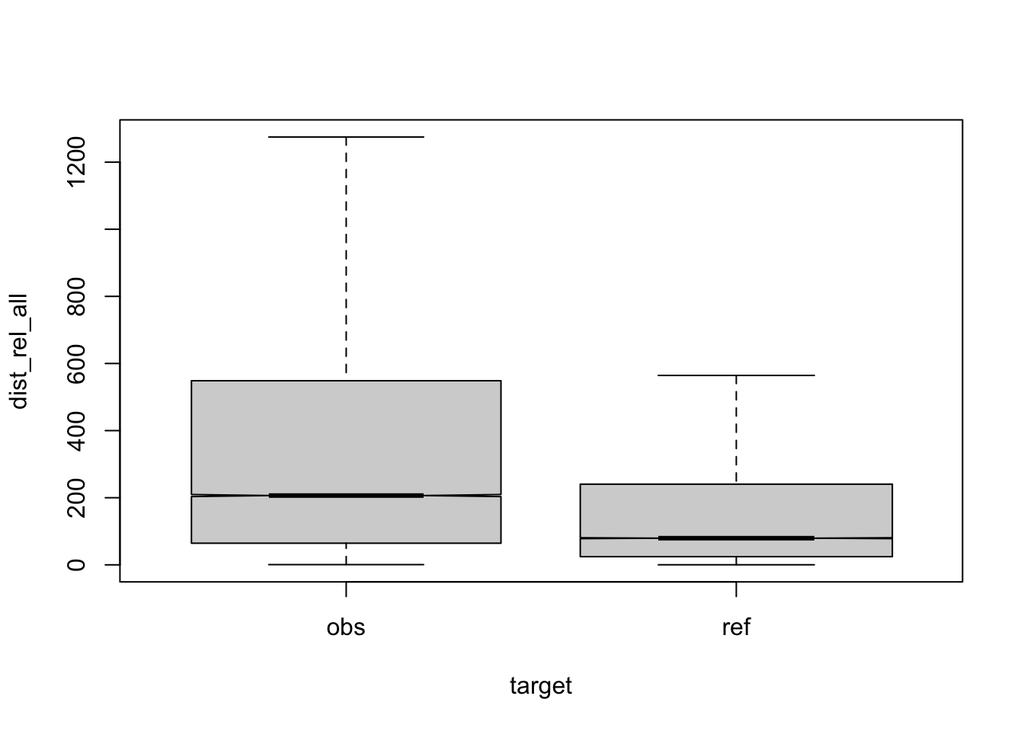

compare distances by corpus, normalised to all, distance ceiling = outliers removed

mean/median table for model: 3

| target | q | n | mean | median |
| --- | --- | --- | --- | --- |
| obs | a | 42836 | 161 | 77 |
| ref | a | 58615 | 172 | 81 |
| obs | b | 2116 | 169 | 109 |
| ref | b | 1130 | 168 | 78 |
| obs | c | 5770 | 159 | 75 |
| ref | c | 1274 | 175 | 84 |
| obs | d | 5654 | 170 | 86 |
| ref | d | 1525 | 176 | 83 |
| obs | e | 3911 | 175 | 92 |
| ref | e | 671 | 165 | 71 |
| obs | f | 2311 | 144 | 62 |
| ref | f | 413 | 171 | 82 |

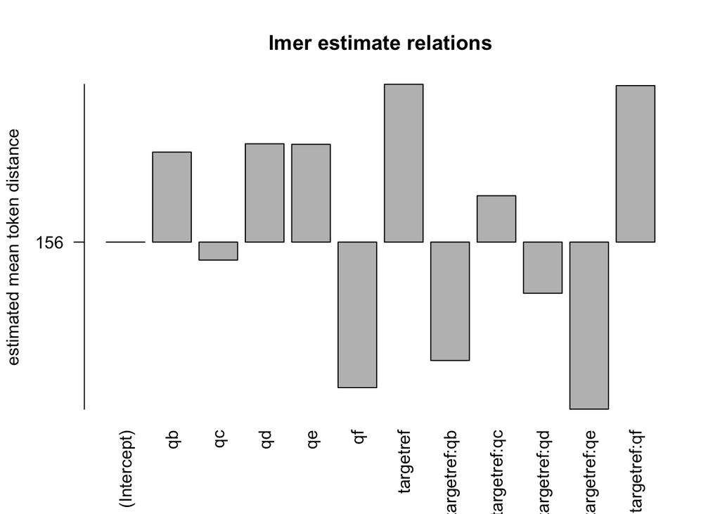

distances relation, normalised to all, distance ceiling = outliers removed

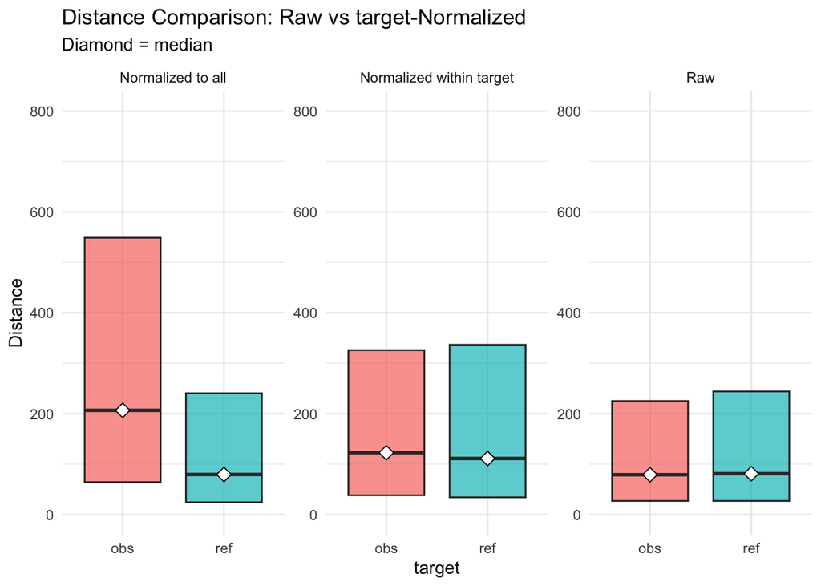

distances normalised vs. raw

## evaluation model: 4

### meta

eval output data: 13, normalised to ref, distance ceiling = outliers removed

### parameter setting

```
##                value
## norm_target _rel_ref
## det.t           TRUE
## limit           TRUE
## author          TRUE
## url             TRUE
## embed1          TRUE
## embed2             f
## range1          TRUE
## range2             f
## rel             TRUE
## lme            FALSE
## lemma          FALSE
```

### anova analysis

#### anova plain

formula: [`dist_rel_ref ~ target*q*det`]

```
##                  Df     Sum Sq    Mean Sq   F value    Pr(>F)
## target            1 2.5135e+09 2513546743 7336.4625 < 2.2e-16 ***
## q                 5 6.8469e+07   13693706   39.9688 < 2.2e-16 ***
## det               1 9.0922e+06    9092198   26.5380 2.588e-07 ***
## target:q          5 1.5268e+07    3053543    8.9126 1.786e-08 ***
## target:det        1 1.3965e+06    1396511    4.0761  0.043496 *
## q:det             2 5.0309e+06    2515448    7.3420  0.000648 ***
## target:q:det      1 3.9858e+06    3985754   11.6335  0.000648 ***
## Residuals    126209 4.3240e+10     342610
## ---
## Signif. codes:  0 '***' 0.001 '**' 0.01 '*' 0.05 '.' 0.1 ' ' 1
```

#### anova of linear regression model

[`anova(summary(lmer))`]

```
## Type III Analysis of Variance Table with Satterthwaite's method
##                 Sum Sq   Mean Sq NumDF  DenDF   F value    Pr(>F)
## target         6358663   6358663     1   3519   23.4567 1.333e-06 ***
## q              4098347    819669     5 122421    3.0237 0.0098706 **
## det              67605     67605     1 118425    0.2494 0.6175055
## range        280081405 280081405     1   1025 1033.2042 < 2.2e-16 ***
## embed.score  139496414 139496414     1 122690  514.5942 < 2.2e-16 ***
## target:q       4314256    862851     5 123486    3.1830 0.0070933 **
## target:det     3006886   3006886     1 123325   11.0922 0.0008672 ***
## q:det          1997926    998963     2 120804    3.6851 0.0250971 *
## target:q:det   1221717   1221717     1 123315    4.5068 0.0337615 *
## ---
## Signif. codes:  0 '***' 0.001 '**' 0.01 '*' 0.05 '.' 0.1 ' ' 1
```

#### linear regression coefficients

formula: [`dist_rel_ref ~ target*q*det+(1|aut_id)+range+(embed.score)+(1|url_id)`]

```
## Linear mixed model fit by REML. t-tests use Satterthwaite's method ['lmerModLmerTest']
## Formula: eval(expr(lmeform))
##    Data: dfa
##
## REML criterion at convergence: 1944105
##
## Scaled residuals:
##     Min      1Q  Median      3Q     Max
## -2.8643 -0.5282 -0.1721  0.2469  6.9244
##
## Random effects:
##  Groups   Name        Variance Std.Dev.
##  aut_id   (Intercept)  15871   126.0
##  url_id   (Intercept)  45496   213.3
##  Residual             271080   520.7
## Number of obs: 126226, groups:  aut_id, 8238; url_id, 2145
##
## Fixed effects:
##                    Estimate Std. Error         df t value Pr(>|t|)
## (Intercept)       1.090e+03  1.216e+01  8.969e+03  89.651  < 2e-16 ***
## targetref        -1.024e+02  1.485e+01  1.300e+03  -6.893 8.50e-12 ***
## qb               -4.744e+01  3.600e+01  1.218e+05  -1.318 0.187483
## qc               -5.203e+01  1.296e+01  1.226e+05  -4.014 5.98e-05 ***
## qd               -7.492e+01  5.246e+02  1.184e+05  -0.143 0.886426
## qe                5.876e+01  9.042e+00  1.247e+05   6.498 8.14e-11 ***
## qf               -4.458e+01  1.153e+01  1.244e+05  -3.866 0.000111 ***
## det               3.001e+01  1.125e+01  1.229e+05   2.667 0.007662 **
## range            -1.370e-01  4.261e-03  1.025e+03 -32.143  < 2e-16 ***
## embed.score      -4.311e+00  1.900e-01  1.227e+05 -22.685  < 2e-16 ***
## targetref:qb      4.389e+01  4.051e+01  1.225e+05   1.083 0.278599
## targetref:qc      5.378e+01  3.015e+01  1.237e+05   1.784 0.074435 .
## targetref:qd      1.040e+00  2.957e+01  1.238e+05   0.035 0.971935
## targetref:qe     -5.472e+01  2.242e+01  1.239e+05  -2.441 0.014662 *
## targetref:qf      4.246e+01  2.853e+01  1.238e+05   1.488 0.136766
## targetref:det    -3.485e+01  2.556e+01  1.239e+05  -1.363 0.172784
## qb:det            1.394e+02  3.955e+01  1.219e+05   3.526 0.000423 ***
## qd:det            8.600e+01  5.244e+02  1.184e+05   0.164 0.869736
## targetref:qb:det -1.225e+02  5.772e+01  1.233e+05  -2.123 0.033761 *
## ---
## Signif. codes:  0 '***' 0.001 '**' 0.01 '*' 0.05 '.' 0.1 ' ' 1
## fit warnings:
## fixed-effect model matrix is rank deficient so dropping 7 columns / coefficients
## Some predictor variables are on very different scales: consider rescaling
```

### plots

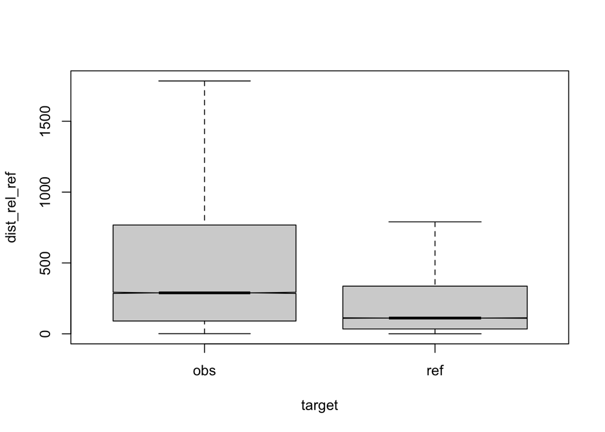

compare distances by corpus, normalised to ref, distance ceiling = outliers removed

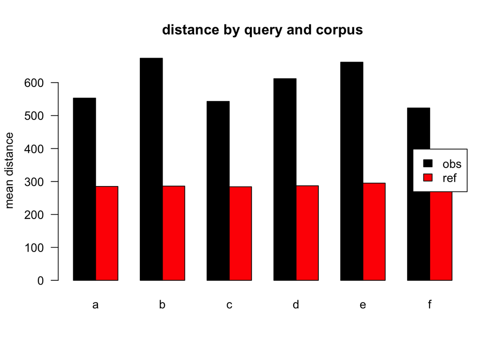

mean distances over query/corpus, normalised to ref, distance ceiling = outliers removed

mean/median table for model: 4

| target | q | n | mean | median |
| --- | --- | --- | --- | --- |
| obs | a | 42836 | 553 | 275 |
| ref | a | 58615 | 285 | 111 |
| obs | b | 2116 | 674 | 390 |
| ref | b | 1130 | 286 | 104 |
| obs | c | 5770 | 543 | 268 |
| ref | c | 1274 | 284 | 112 |
| obs | d | 5654 | 612 | 340 |
| ref | d | 1525 | 287 | 116 |
| obs | e | 3911 | 662 | 347 |
| ref | e | 671 | 295 | 105 |
| obs | f | 2311 | 523 | 313 |
| ref | f | 413 | 273 | 111 |

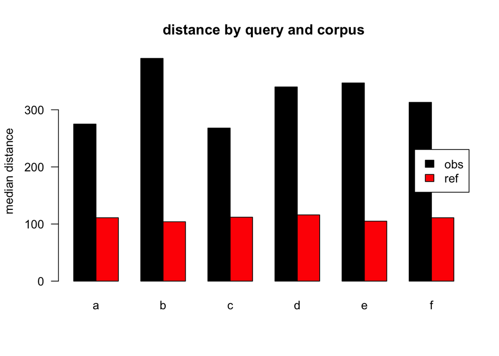

median distances over query/corpus, normalised to ref, distance ceiling = outliers removed

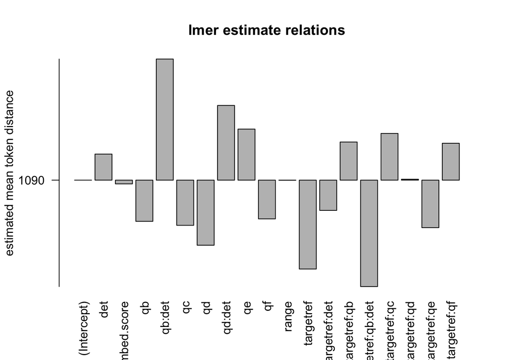

distances relation, normalised to ref, distance ceiling = outliers removed

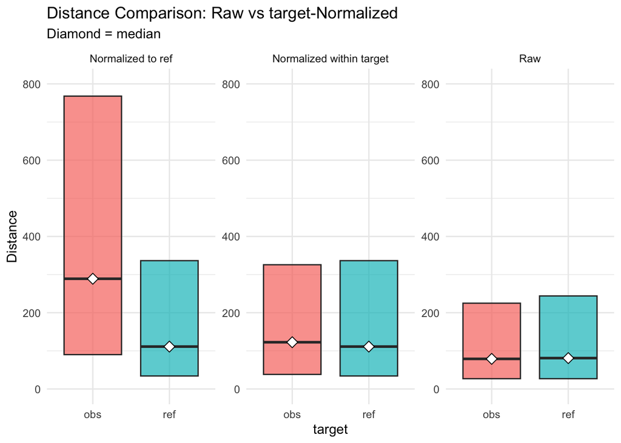

distances normalised vs. raw

## evaluation model: 6

### meta

eval output data: 13, not normalised, distance ceiling =outliers removed

### parameter setting

```
##             value
## norm_target
## det.t        TRUE
## limit        TRUE
## author       TRUE
## url          TRUE
## embed1       TRUE
## embed2          f
## range1       TRUE
## range2          f
## rel         FALSE
## lme         FALSE
## lemma       FALSE
```

### anova analysis

#### anova plain

formula: [`dist ~ target*q*det`]

```
##                  Df     Sum Sq Mean Sq F value    Pr(>F)
## target            1    3284330 3284330 84.1223 < 2.2e-16 ***
## q                 5    1633205  326641  8.3663  6.39e-08 ***
## det               1     431404  431404 11.0496 0.0008873 ***
## target:q          5     441118   88224  2.2597 0.0457798 *
## target:det        1      16732   16732  0.4286 0.5126999
## q:det             2      25549   12774  0.3272 0.7209470
## target:q:det      1       6009    6009  0.1539 0.6948226
## Residuals    126209 4927490433   39042
## ---
## Signif. codes:  0 '***' 0.001 '**' 0.01 '*' 0.05 '.' 0.1 ' ' 1
```

#### anova of linear regression model

[`anova(summary(lmer))`]

```
## Type III Analysis of Variance Table with Satterthwaite's method
##                Sum Sq  Mean Sq NumDF  DenDF   F value Pr(>F)
## target            218      218     1  17034    0.0061 0.9377
## q              109358    21872     5 124317    0.6129 0.6901
## det             20678    20678     1 121247    0.5794 0.4465
## range        15332432 15332432     1    912  429.6377 <2e-16 ***
## embed.score  77286240 77286240     1 105351 2165.6761 <2e-16 ***
## target:q       304923    60985     5 125126    1.7089 0.1287
## target:det      17833    17833     1 124982    0.4997 0.4796
## q:det           37151    18576     2 123066    0.5205 0.5942
## target:q:det    23985    23985     1 124972    0.6721 0.4123
## ---
## Signif. codes:  0 '***' 0.001 '**' 0.01 '*' 0.05 '.' 0.1 ' ' 1
```

#### linear regression coefficients

formula: [`dist ~ target*q*det+(1|aut_id)+range+(embed.score)+(1|url_id)`]

```
## Linear mixed model fit by REML. t-tests use Satterthwaite's method ['lmerModLmerTest']
## Formula: eval(expr(lmeform))
##    Data: dfa
##
## REML criterion at convergence: 1685342
##
## Scaled residuals:
##     Min      1Q  Median      3Q     Max
## -2.0402 -0.6622 -0.3317  0.3419  4.1697
##
## Random effects:
##  Groups   Name        Variance Std.Dev.
##  aut_id   (Intercept)  1394     37.34
##  url_id   (Intercept)  1072     32.74
##  Residual             35687    188.91
## Number of obs: 126226, groups:  aut_id, 8238; url_id, 2145
##
## Fixed effects:
##                    Estimate Std. Error         df t value Pr(>|t|)
## (Intercept)       2.533e+02  3.618e+00  1.966e+04  70.000  < 2e-16 ***
## targetref         1.326e+00  2.954e+00  1.890e+03   0.449  0.65362
## qb               -8.195e+00  1.300e+01  1.239e+05  -0.630  0.52845
## qc               -8.144e+00  4.675e+00  1.243e+05  -1.742  0.08150 .
## qd               -1.117e+02  1.902e+02  1.212e+05  -0.587  0.55726
## qe                1.392e+01  3.248e+00  1.256e+05   4.285 1.83e-05 ***
## qf               -6.628e+00  4.145e+00  1.253e+05  -1.599  0.10981
## det               3.793e+00  4.058e+00  1.245e+05   0.935  0.35005
## range             1.535e-02  7.406e-04  9.124e+02  20.728  < 2e-16 ***
## embed.score      -3.110e+00  6.682e-02  1.054e+05 -46.537  < 2e-16 ***
## targetref:qb      4.017e+00  1.464e+01  1.244e+05   0.274  0.78373
## targetref:qc      4.577e+00  1.089e+01  1.253e+05   0.420  0.67442
## targetref:qd     -2.061e+00  1.069e+01  1.253e+05  -0.193  0.84707
## targetref:qe     -2.134e+01  8.099e+00  1.255e+05  -2.635  0.00841 **
## targetref:qf      8.889e+00  1.031e+01  1.254e+05   0.862  0.38849
## targetref:det     1.178e+00  9.236e+00  1.253e+05   0.127  0.89855
## qb:det            1.714e+01  1.428e+01  1.239e+05   1.200  0.23002
## qd:det            1.126e+02  1.902e+02  1.212e+05   0.592  0.55380
## targetref:qb:det -1.710e+01  2.086e+01  1.250e+05  -0.820  0.41233
## ---
## Signif. codes:  0 '***' 0.001 '**' 0.01 '*' 0.05 '.' 0.1 ' ' 1
## fit warnings:
## fixed-effect model matrix is rank deficient so dropping 7 columns / coefficients
## Some predictor variables are on very different scales: consider rescaling
```

### plots

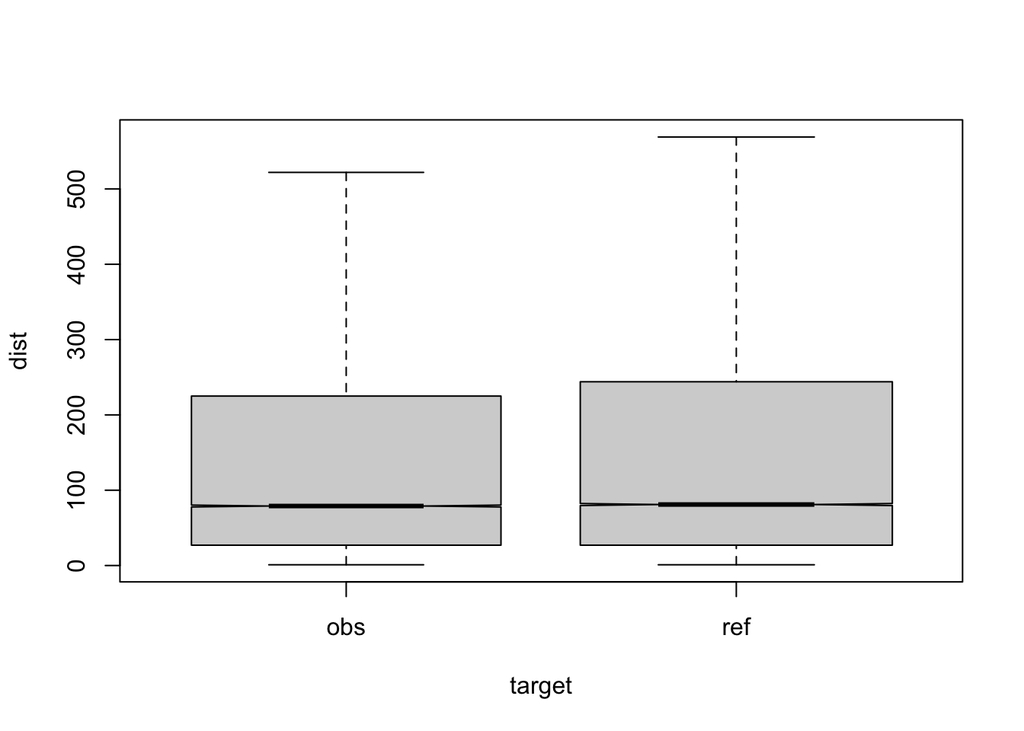

compare distances by corpus, not normalised, distance ceiling =outliers removed

mean/median table for model: 6

| target | q | n | mean | median |
| --- | --- | --- | --- | --- |
| obs | a | 42836 | 161 | 77 |
| ref | a | 58615 | 172 | 81 |
| obs | b | 2116 | 169 | 109 |
| ref | b | 1130 | 168 | 78 |
| obs | c | 5770 | 159 | 75 |
| ref | c | 1274 | 175 | 84 |
| obs | d | 5654 | 170 | 86 |
| ref | d | 1525 | 176 | 83 |
| obs | e | 3911 | 175 | 92 |
| ref | e | 671 | 165 | 71 |
| obs | f | 2311 | 144 | 62 |
| ref | f | 413 | 171 | 82 |

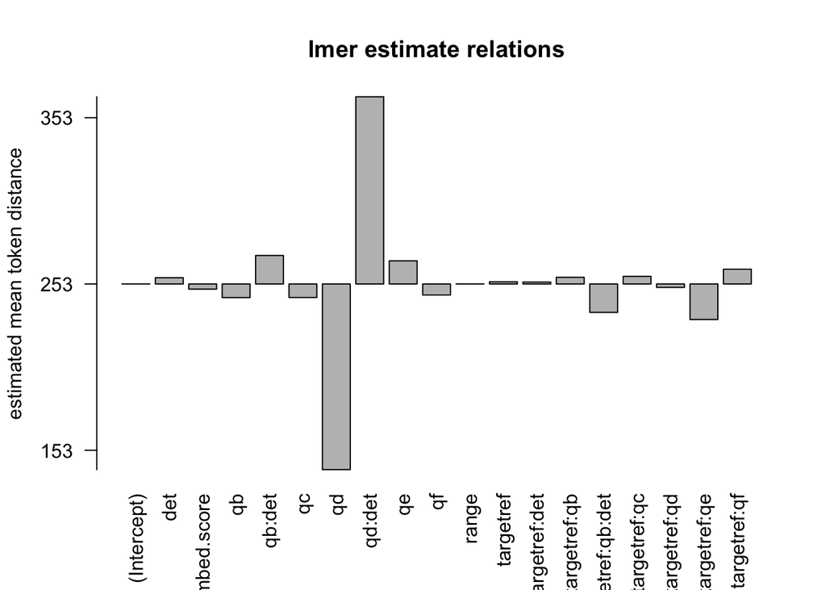

distances relation, not normalised, distance ceiling =outliers removed

## evaluation model: 8

### meta

eval output data: 13, normalised to obs, distance ceiling = outliers removed

### parameter setting

```
##                value
## norm_target _rel_obs
## det.t           TRUE
## limit           TRUE
## author          TRUE
## url             TRUE
## embed1          TRUE
## embed2             f
## range1          TRUE
## range2             f
## rel             TRUE
## lme            FALSE
## lemma          FALSE
```

### anova analysis

#### anova plain

formula: [`dist_rel_obs ~ target*q*det`]

```
##                  Df     Sum Sq   Mean Sq   F value    Pr(>F)
## target            1  452303747 452303747 7336.4625 < 2.2e-16 ***
## q                 5   12320667   2464133   39.9688 < 2.2e-16 ***
## det               1    1636109   1636109   26.5380 2.588e-07 ***
## target:q          5    2747371    549474    8.9126 1.786e-08 ***
## target:det        1     251297    251297    4.0761  0.043496 *
## q:det             2     905292    452646    7.3420  0.000648 ***
## target:q:det      1     717222    717222   11.6335  0.000648 ***
## Residuals    126209 7780971239     61651
## ---
## Signif. codes:  0 '***' 0.001 '**' 0.01 '*' 0.05 '.' 0.1 ' ' 1
```

#### anova of linear regression model

[`anova(summary(lmer))`]

```
## Type III Analysis of Variance Table with Satterthwaite's method
##                Sum Sq  Mean Sq NumDF  DenDF   F value    Pr(>F)
## target        1144219  1144219     1   3519   23.4567 1.333e-06 ***
## q              737483   147497     5 122421    3.0237 0.0098706 **
## det             12165    12165     1 118425    0.2494 0.6175055
## range        50399647 50399647     1   1025 1033.2042 < 2.2e-16 ***
## embed.score  25101881 25101881     1 122690  514.5942 < 2.2e-16 ***
## target:q       776335   155267     5 123486    3.1830 0.0070933 **
## target:det     541078   541078     1 123325   11.0922 0.0008672 ***
## q:det          359520   179760     2 120804    3.6851 0.0250971 *
## target:q:det   219844   219844     1 123315    4.5068 0.0337615 *
## ---
## Signif. codes:  0 '***' 0.001 '**' 0.01 '*' 0.05 '.' 0.1 ' ' 1
```

#### linear regression coefficients

formula: [`dist_rel_obs ~ target*q*det+(1|aut_id)+range+(embed.score)+(1|url_id)`]

```
## Linear mixed model fit by REML. t-tests use Satterthwaite's method ['lmerModLmerTest']
## Formula: eval(expr(lmeform))
##    Data: dfa
##
## REML criterion at convergence: 1727648
##
## Scaled residuals:
##     Min      1Q  Median      3Q     Max
## -2.8643 -0.5282 -0.1721  0.2469  6.9244
##
## Random effects:
##  Groups   Name        Variance Std.Dev.
##  aut_id   (Intercept)  2856     53.44
##  url_id   (Intercept)  8187     90.48
##  Residual             48780    220.86
## Number of obs: 126226, groups:  aut_id, 8238; url_id, 2145
##
## Fixed effects:
##                    Estimate Std. Error         df t value Pr(>|t|)
## (Intercept)       4.625e+02  5.159e+00  8.969e+03  89.651  < 2e-16 ***
## targetref        -4.342e+01  6.299e+00  1.300e+03  -6.893 8.50e-12 ***
## qb               -2.013e+01  1.527e+01  1.218e+05  -1.318 0.187483
## qc               -2.207e+01  5.499e+00  1.226e+05  -4.014 5.98e-05 ***
## qd               -3.178e+01  2.225e+02  1.184e+05  -0.143 0.886426
## qe                2.492e+01  3.835e+00  1.247e+05   6.498 8.14e-11 ***
## qf               -1.891e+01  4.892e+00  1.244e+05  -3.866 0.000111 ***
## det               1.273e+01  4.774e+00  1.229e+05   2.667 0.007662 **
## range            -5.810e-02  1.808e-03  1.025e+03 -32.143  < 2e-16 ***
## embed.score      -1.829e+00  8.061e-02  1.227e+05 -22.685  < 2e-16 ***
## targetref:qb      1.862e+01  1.719e+01  1.225e+05   1.083 0.278599
## targetref:qc      2.281e+01  1.279e+01  1.237e+05   1.784 0.074435 .
## targetref:qd      4.413e-01  1.254e+01  1.238e+05   0.035 0.971935
## targetref:qe     -2.321e+01  9.511e+00  1.239e+05  -2.441 0.014662 *
## targetref:qf      1.801e+01  1.210e+01  1.238e+05   1.488 0.136766
## targetref:det    -1.478e+01  1.084e+01  1.239e+05  -1.363 0.172784
## qb:det            5.915e+01  1.678e+01  1.219e+05   3.526 0.000423 ***
## qd:det            3.648e+01  2.225e+02  1.184e+05   0.164 0.869736
## targetref:qb:det -5.198e+01  2.448e+01  1.233e+05  -2.123 0.033761 *
## ---
## Signif. codes:  0 '***' 0.001 '**' 0.01 '*' 0.05 '.' 0.1 ' ' 1
## fit warnings:
## fixed-effect model matrix is rank deficient so dropping 7 columns / coefficients
## Some predictor variables are on very different scales: consider rescaling
```

### plots

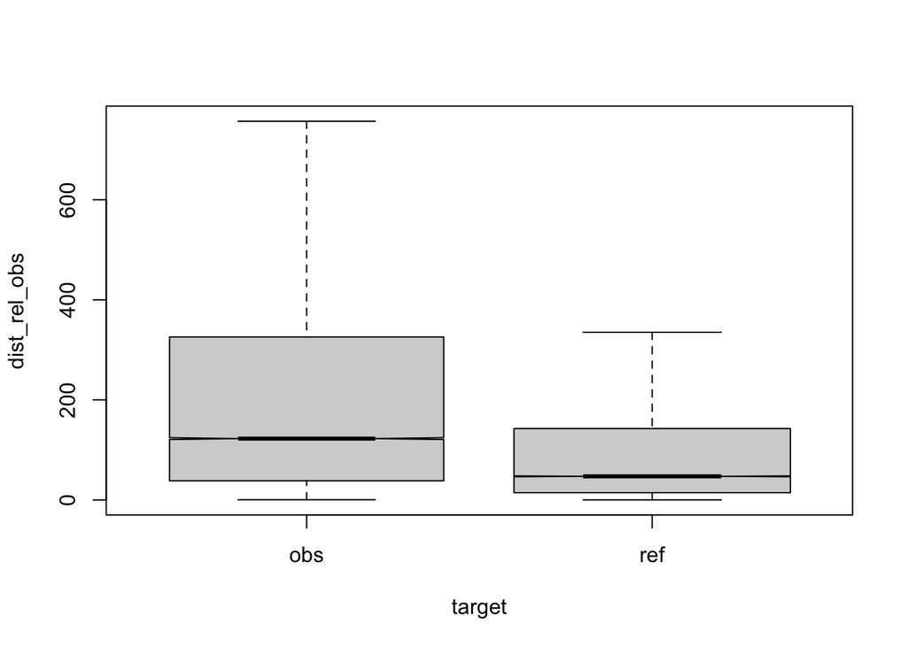

compare distances by corpus, normalised to obs, distance ceiling = outliers removed

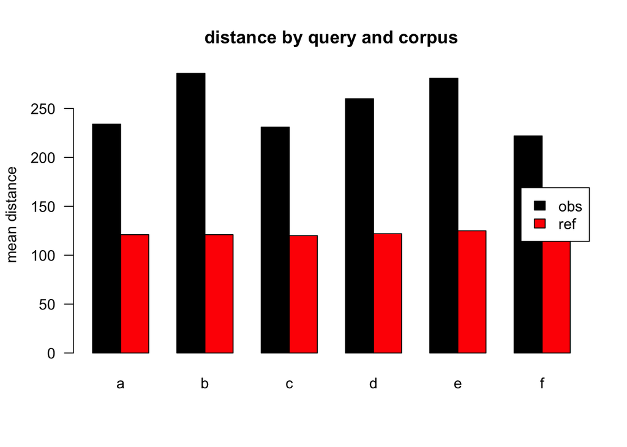

mean distances over query/corpus, normalised to obs, distance ceiling = outliers removed

mean/median table for model: 8

| target | q | n | mean | median |
| --- | --- | --- | --- | --- |
| obs | a | 42836 | 234 | 117 |
| ref | a | 58615 | 121 | 47 |
| obs | b | 2116 | 286 | 165 |
| ref | b | 1130 | 121 | 44 |
| obs | c | 5770 | 231 | 114 |
| ref | c | 1274 | 120 | 48 |
| obs | d | 5654 | 260 | 144 |
| ref | d | 1525 | 122 | 49 |
| obs | e | 3911 | 281 | 147 |
| ref | e | 671 | 125 | 45 |
| obs | f | 2311 | 222 | 133 |
| ref | f | 413 | 116 | 47 |

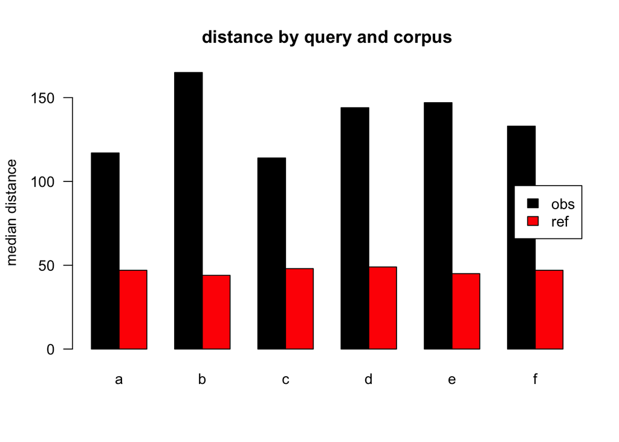

median distances over query/corpus, normalised to obs, distance ceiling = outliers removed

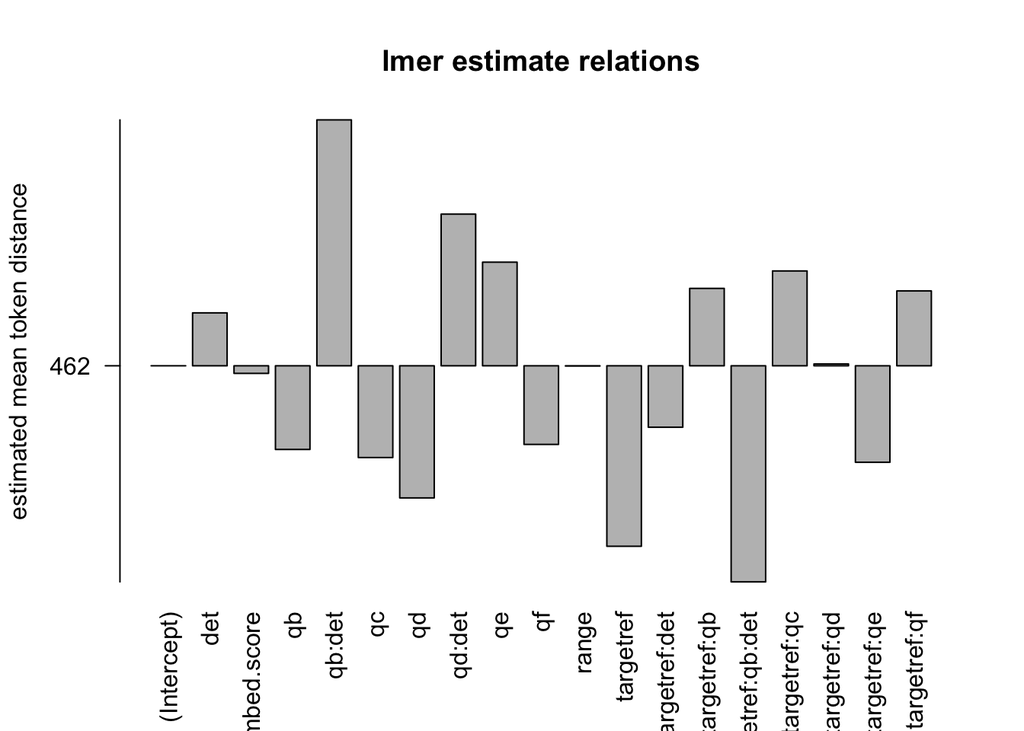

distances relation, normalised to obs, distance ceiling = outliers removed

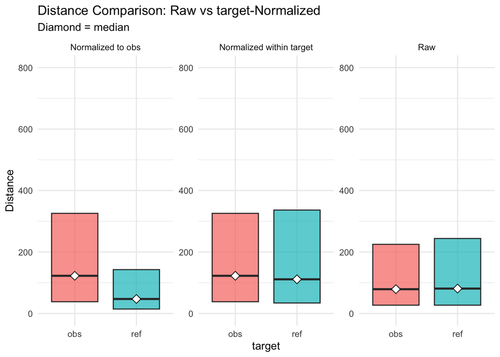

distances normalised vs. raw

## Selbständigkeit: benutzte Hilfestellung

In der vorliegenden Arbeit wurden keinerlei nicht erlaubte Hilfsmittel zur Erstellung von Inhalten verwendet. Die Benutzung von KI beschränkt sich auf (Tabelle):

verwendete Hilfsmittel

| Hilfsmittel | Verwendung |
| --- | --- |
| github copilot | Hilfe bei der Skripterstellung (R, Python) zur Programmierung der Distanzenberechnung, semantic embeddings und statistischen Auswertung |
| chatgpt.com | dito |
| claude.ai | dito |
| deepseek.com | dito |
| nomic-embed-text (model) | calculate semantic embeddings |

## references

literature used and alii…

Bates, Douglas, Martin Mächler, Ben Bolker, and Steve Walker. 2015. “Fitting Linear Mixed-Effects Models Using Lme4.” *Journal of Statistical Software* 67 (1): 1–48. https://doi.org/10.18637/jss.v067.i01.

De Marneffe, Marie-Catherine, Christopher D. Manning, Joakim Nivre, and Daniel Zeman. 2021. “Universal Dependencies.” *Computational Linguistics*, May, 1–54. https://doi.org/10.1162/coli_a_00402.

HuggingFace. 2025. “All-MiniLM-L6-V2 · Hugging Face.” In *Sentence Transformers*. https://huggingface.co/sentence-transformers/all-MiniLM-L6-v2.

Kjell, Oscar, Salvatore Giorgi, and H. Andrew Schwartz. 2023. “The Text-Package: An R-Package for Analyzing and Visualizing Human Language Using Natural Language Processing and Deep Learning.” *Psychological Methods*, ahead of print. https://doi.org/10.1037/met0000542.

Kuperberg, Gina R. 2010. “Language in Schizophrenia Part 2: What Can Psycholinguistics Bring to the Study of Schizophrenia…and Vice Versa?” *Language and Linguistics Compass* 4 (8): 590–604. https://doi.org/10.1111/j.1749-818X.2010.00217.x.

Lee, Kenton, Luheng He, and Luke Zettlemoyer. 2018. *Higher-Order Coreference Resolution with Coarse-to-Fine Inference*. arXiv. https://doi.org/10.48550/arXiv.1804.05392.

Maindonald, John H., W. John Braun, and Jeffrey L. Andrews. 2024. *A Practical Guide to Data Analysis Using R: An Example-Based Approach*. Cambridge University Press.

Mishara, Aaron L. 2010. “Klaus Conrad (1905–1961): Delusional Mood, Psychosis, and Beginning Schizophrenia.” *Schizophrenia Bulletin* 36 (1): 9–13. https://doi.org/10.1093/schbul/sbp144.

Nenchev, Ivan, Tatjana Scheffler, Marie de la Fuente, et al. 2024. “Linguistic Markers of Schizophrenia: A Case Study of Robert Walser.” In *Proceedings of the 9th Workshop on Computational Linguistics and Clinical Psychology (CLPsych 2024)*, edited by Andrew Yates, Bart Desmet, Emily Prud’hommeaux, et al. Association for Computational Linguistics. https://aclanthology.org/2024.clpsych-1.4/.

*Nomic-Ai/Nomic-Embed-Text-V1.5 · Hugging Face*. 2024. https://huggingface.co/nomic-ai/nomic-embed-text-v1.5.

*Nomic-Embed-Text*. n.d. Accessed October 6, 2025. https://ollama.com/nomic-embed-text.

Nussbaum, Zach, John X. Morris, Brandon Duderstadt, and Andriy Mulyar. 2024. *Nomic Embed: Training a Reproducible Long Context Text Embedder*. https://huggingface.co/nomic-ai/nomic-embed-text-v1.5.

ottiram. 2025. *Ottiram/MMAX2*. https://github.com/ottiram/MMAX2.

Poesio, Massimo, Artstein, Ron, Uryupina, Olga, et al. 2013. *The ARRAU Corpus of Anaphoric Information*. Linguistic Data Consortium. https://doi.org/10.35111/Y3MR-HE10.

Prince, Ellen F. 1981. “Toward a Taxonomy of Given-New Information.” In *Syntax and Semantics: Vol. 14. Radical Pragmatics*, edited by P. Cole. Academic Press.

Rivera, Ivan. 2023. *RedditExtractoR: Reddit Data Extraction Toolkit*. https://CRAN.R-project.org/package=RedditExtractoR.

Schwarz, St. 2025. *Poster Appendix: This Papers Scripts for Corpus Build and Statistics on Github.* https://github.com/esteeschwarz/SPUND-LX/tree/main/psych/HA.

Wijffels, Jan. 2023. *Udpipe: Tokenization, Parts of Speech Tagging, Lemmatization and Dependency Parsing with the ’UDPipe’ ’NLP’ Toolkit*. https://CRAN.R-project.org/package=udpipe.

Zimmerer, Vitor C., Stuart Watson, Douglas Turkington, I. Nicol Ferrier, and Wolfram Hinzen. 2017. “Deictic and Propositional Meaning—New Perspectives on Language in Schizophrenia.” *Frontiers in Psychiatry* 8 (February). https://doi.org/10.3389/fpsyt.2017.00017.

[^1]: due to lack of empathy or a general self-alignment
[^2]: where the participants may show a more realistic estimation of beforementioned ability
[^3]: to prevent stigmatisation of the subreddit users we decided to not name it here.
[^4]: preceded by conditioned determiners
[^5]: informations in a text
[^6]: cf. Prince: speaker assumptions about hearer familiarity = assumed familiarity
[^7]: which should be weaker with growing distance between reference-referent
[^8]: which can be considered as a control condition as it should naturally allow wider distances between the following noun and the reference than all other conditions.
[^9]: this is as of model 1-6 not yet integrated in the analysis
[^10]: only according to the LLM training data, which is still a blackbox
[^11]: to spare ressources
[^12]: where “obs” comes first